# Week 10

Next, I ran the other two lexicons from above and comapred their output to see if there any obvious differences.

```r
bing <- speeches_words %>%
  inner_join(get_sentiments("bing")) %>%
  count(year = year, sentiment) %>%
  pivot_wider(names_from = sentiment, values_from = n, values_fill = 0) %>%
  mutate(sentiment = positive - negative) %>%
  mutate(method = "Bing")
nrc <- speeches_words %>%
  inner_join(get_sentiments("nrc") %>%
                filter(sentiment %in% c("positive", "negative"))) %>%
  count(year = year, sentiment) %>%
  pivot_wider(names_from = sentiment, values_from = n, values_fill = 0) %>%
  mutate(sentiment = positive - negative) %>%
  mutate(method = "NRC")
```

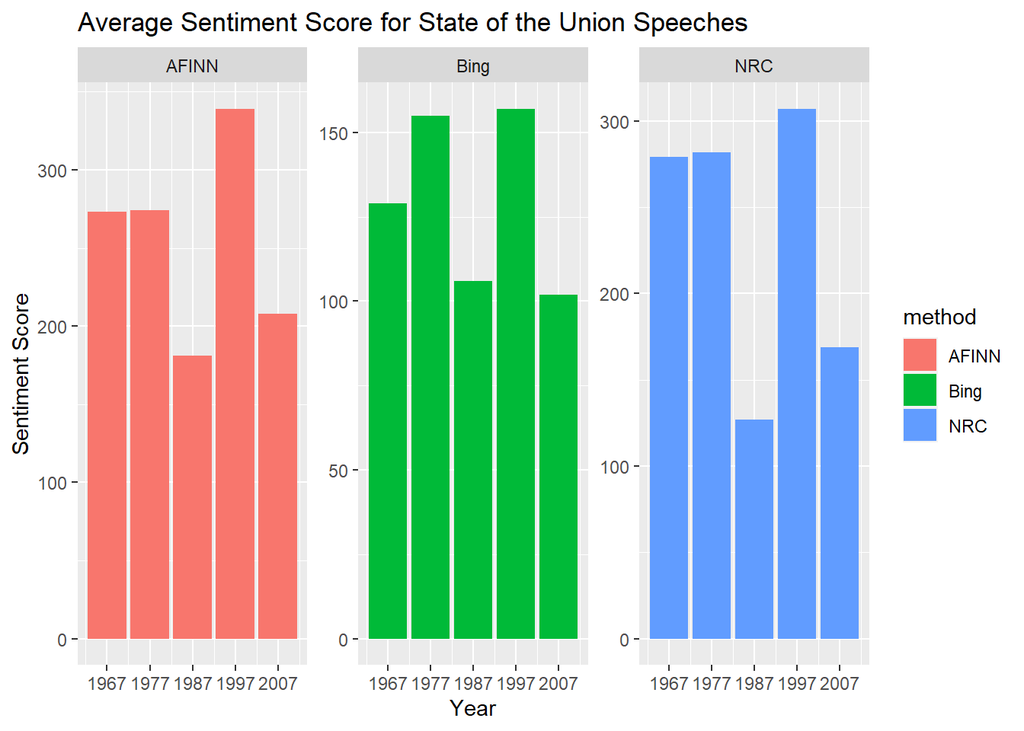

```r
combined_data <- bind_rows(nrc, bing, afinn)

combined_data %>%
  ggplot(aes(x = year, y = sentiment, fill = method)) +
  geom_col() +
  labs(title = "Average Sentiment Score for State of the Union Speeches",
       x = "Year",
       y = "Sentiment Score") +
  facet_wrap(~method, scales = "free_y") +
  scale_x_continuous(breaks = unique(combined_data$year))
```

I was curious if the reason the 1987 address was so much more negative relative to the others was due to a spefifc word measured wrongly due to being a more commonly used word at the time. In order to check that, I ran similar code as in Part 1 to see the top 10 negative and positive words.

```r
bing_word_counts1 <- speeches_words %>%
  filter(year == 1987) %>%
  inner_join(get_sentiments("bing")) %>%
  count(word, sentiment, sort = TRUE) %>%
  ungroup()
```

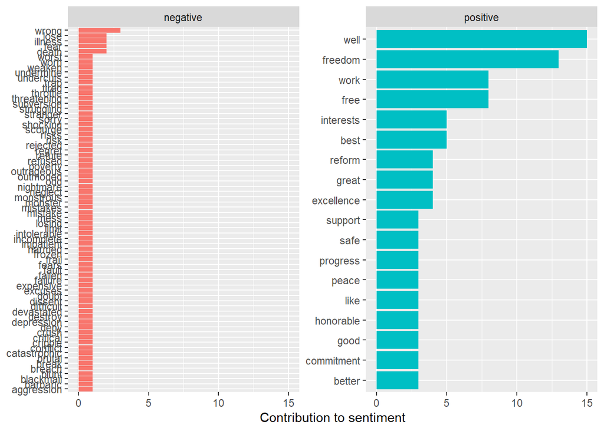

```r
bing_word_counts1 %>%
  group_by(sentiment) %>%
  slice_max(n, n = 10) %>%
  ungroup() %>%
  mutate(word = reorder(word, n)) %>%
  ggplot(aes(n, word, fill = sentiment)) +
  geom_col(show.legend = FALSE) +
  facet_wrap(~sentiment, scales = "free_y") +
  labs(x = "Contribution to sentiment",
       y = NULL)
```

While I only asked ggplot to plot the 10 most common words, that isn’t what I got. In both the positive and negative plots, my output was more than the 10 I requested. The reason for that was due to there being a tie in the top 10. The sheer amount of words tying in the negative column disproves my theory about one word impacting the analysis too much. I must conclude that the contents of the address was indeed much more negative than the other years.

The NRC lexicon has a variety of different sentiments it measures in addition to positive and negative. I will later include a plot with all of them. What I wanted to do next was use the NRC lexicon to analyze the relationship between the trust sentiment relative to the fear sentiment and see if there is a relationship between that and the positive/negative sentiment.

```r
nrc_trust <- speeches_words %>%
  inner_join(get_sentiments("nrc") %>%
                filter(sentiment %in% c("trust", "fear"))) %>%
  count(year = year, sentiment) %>%
  pivot_wider(names_from = sentiment, values_from = n, values_fill = 0) %>%
  mutate(sentiment = trust - fear) %>%
  mutate(method = "NRC")
```

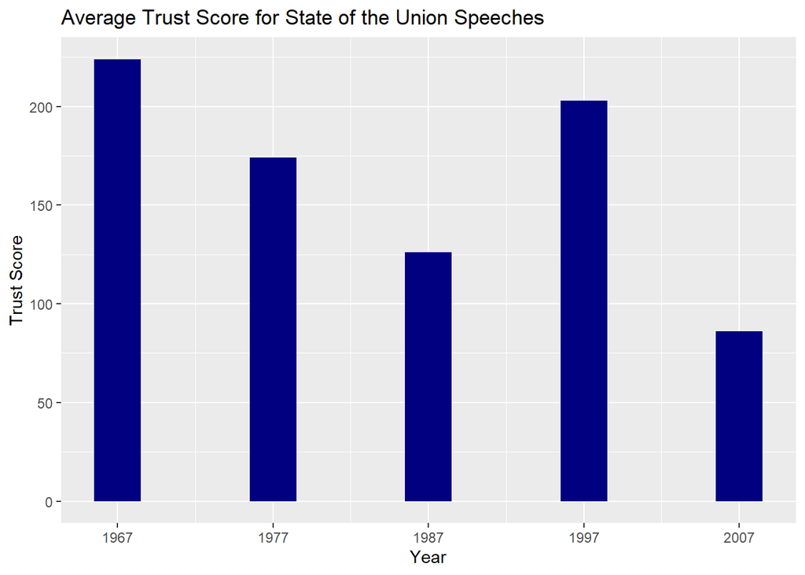

```r
ggplot(nrc_trust, aes(x = year, y = sentiment)) +
  geom_col(fill = "navy", width = 3) +
  labs(title = "Average Trust Score for State of the Union Speeches",
       x = "Year",
       y = "Trust Score") +
  scale_x_continuous(breaks = nrc_trust$year)
```

Just for completion’s sake, I included a plot of the 10 words most contributing to each of the eight emotions measured by the NRC lexicon. Something noteworthy of the below plot is the disproportionate effect the word “congress” has on the disgust sentiment. For obvious reasons, the word congress will appear many times in an address to congress. If that gets classified as a word that implies disgust, there will be a much higher sentiment of disgust represented than there is in reality. The solution can be to add the word congress to a list of custom stop words as discussed in Part 1.

```r
nrc_word_counts <- speeches_words %>%
  inner_join(get_sentiments("nrc")) %>%
  count(word, sentiment, sort = TRUE) %>%
  ungroup()
```

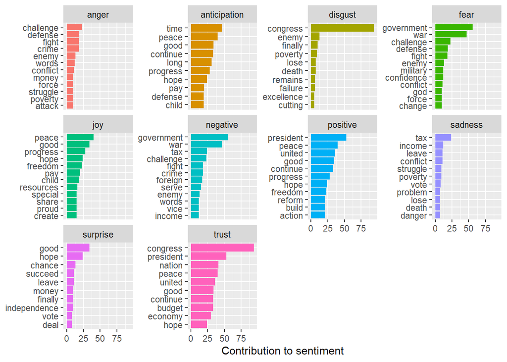

```r
nrc_word_counts %>%
  group_by(sentiment) %>%
  slice_max(n, n = 10) %>%
  ungroup() %>%
  mutate(word = reorder(word, n)) %>%
  ggplot(aes(n, word, fill = sentiment)) +
  geom_col(show.legend = FALSE) +
  facet_wrap(~sentiment, scales = "free_y") +
  labs(x = "Contribution to sentiment",
       y = NULL)
```